# Laptop Battery Life and Charging Habits

This story will show the average battery life of my old laptop and my charging habits which I record everytime I reach over to turn on the charger.

## Data of Recorded Charges

Here is a bar chart showing how many times I recorded the laptop charges by month:

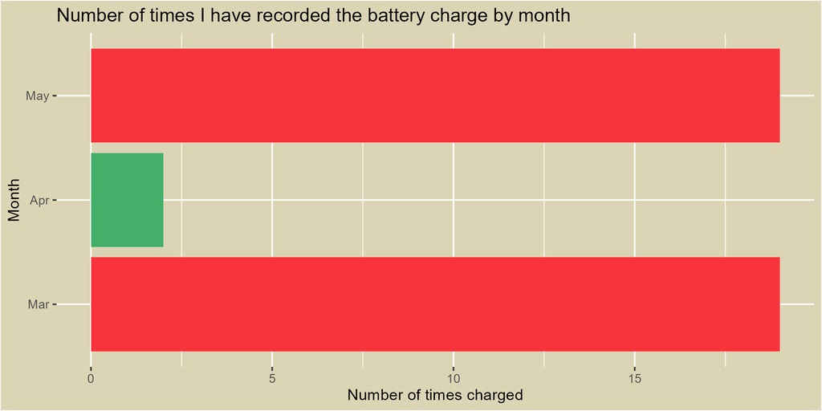

Both March and May have **19** records each which seems about right considering that was during Project 2 and this current project respectively.

## Battery Life

Now lets take a look at how long the laptop battery lasted.

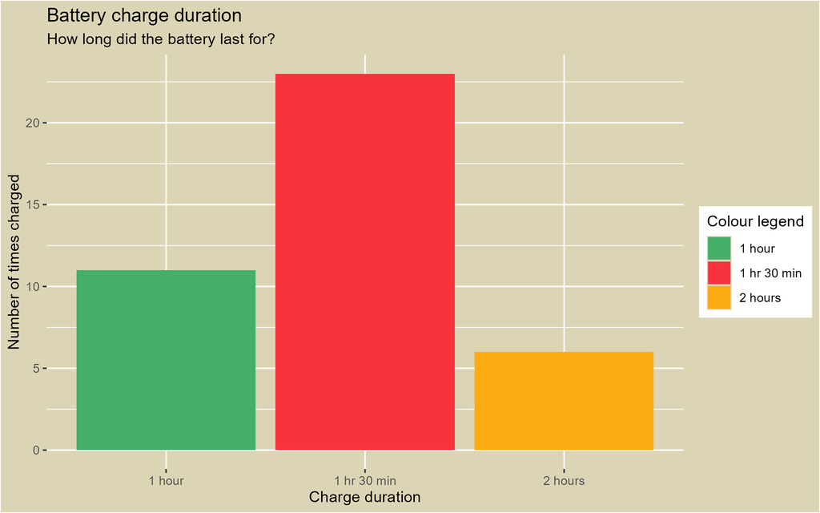

It looks like that on average, the laptop battery lasts **1 hour 30 minutes** with a maximum of 2 hours and a minimum of 1 hour. The battery must be pretty worn down if it only lasts that long but it is a 4 and half year old laptop after all.

## Charging Habits - Battery Percentage

I tend to start charging the laptop battery the most at **21-30%.** Though I do have battery saver mode automatically turn on at 30% which could have influenced when I started charging.

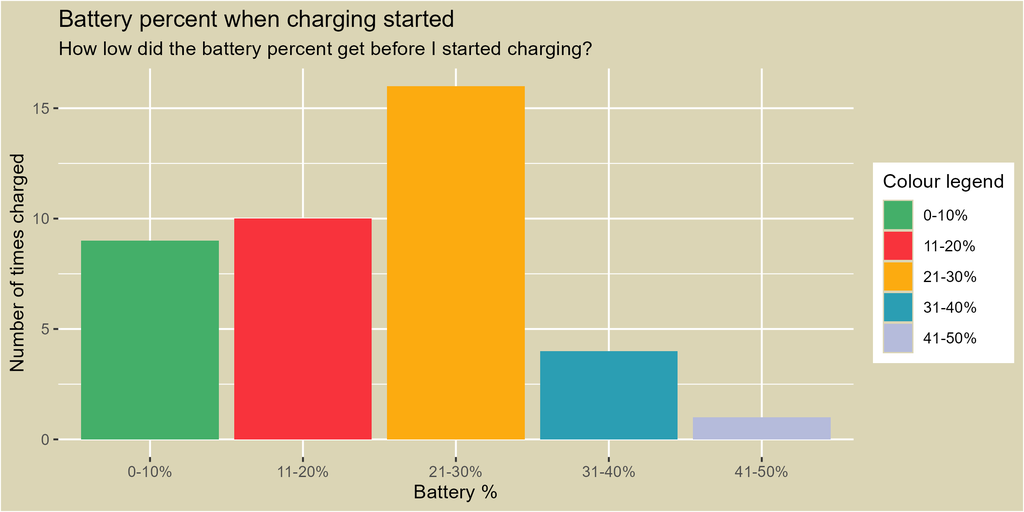

battery percent at beginning of charge

I seem to charge the battery up to **91-100%** for over half my charges. Usually, I want charge to aroud 80% but clearly this data shows that I do not do a very good job at checking how the battery has charged.

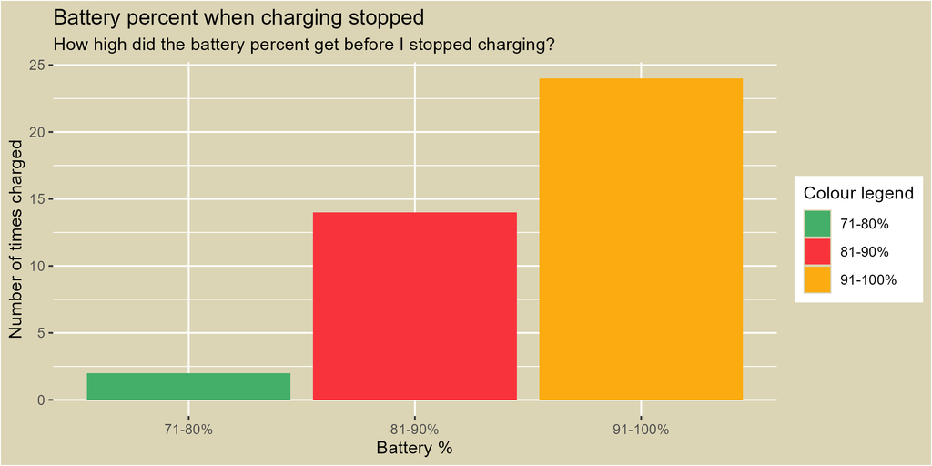

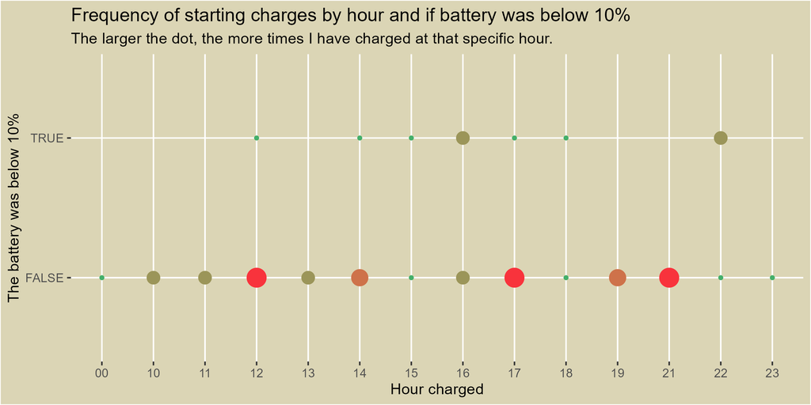

time of charge and if charge was less than ten percent

## Charging Habits - Time of Charge

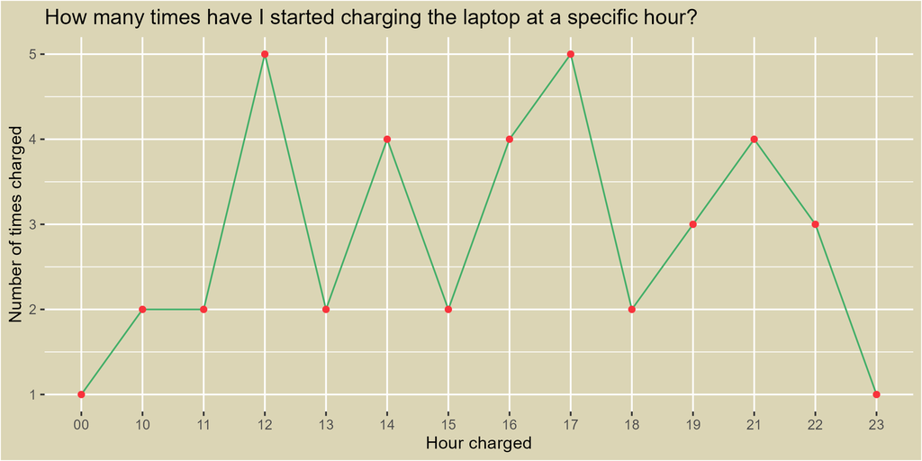

number of times charged at a specific hour